# Week 6: Visualising (estimation) uncertainty

161.307 Reproducible Visualisation for Statistics

School of Mathematical and Computational Sciences, Massey University

17 Aug 2026

```r
library(ggplot2)
library(dplyr)
knitr::opts_chunk$set(dev = "ragg_png")
```

## Recap from Week 5

- Ensembles of simulated trajectories $\to$ spaghetti plots, small multiples, ribbons
- Ribbons summarised *simulation variability* (median + quantile bands)
- This week: the **same visual grammar**, applied to *estimation* uncertainty (CIs, prediction intervals, bootstrap/posterior draws)

# Lecture 1: Sources and types of uncertainty

## Three (at least) kinds of uncertainty

- **Sampling uncertainty**: if I repeated my study, my estimate would differ $\to$ quantified by standard errors / confidence intervals (or Bayesian framework: credible/compatibility intervals)
- **Model uncertainty**: uncertainty about the *form* of the model itself (often not visualised directly)
- **Prediction uncertainty**: uncertainty about a *new* observation, which combines sampling uncertainty with residual variation

## Why the distinction matters for visualisation

A confidence interval and a prediction interval can look identical on a plot (a ribbon) but mean very different things:

- ConfInt: “we’re 95% confident the **mean** response at $x$ is in this range”
- PredInt: “we’re 95% confident a **new observation** at $x$ falls in this range” (wider)

## Why the distinction matters for visualisation

```r
library(ggplot2)
set.seed(1)
x <- seq(0, 10, length.out = 50)
y <- 2 + 0.5 * x + rnorm(50, sd = 1.5)
df <- data.frame(x, y)
fit <- lm(y ~ x, data = df)

pred_ci <- predict(fit, newdata = data.frame(x = x), interval = "confidence")
pred_pi <- predict(fit, newdata = data.frame(x = x), interval = "prediction")

plot_df <- data.frame(
  x = x,
  fit = pred_ci[, "fit"],
  ci_lwr = pred_ci[, "lwr"], ci_upr = pred_ci[, "upr"],
  pi_lwr = pred_pi[, "lwr"], pi_upr = pred_pi[, "upr"]
)

ggplot(plot_df, aes(x)) +
  geom_ribbon(aes(ymin = pi_lwr, ymax = pi_upr), alpha = 0.15, fill = "darkorange") +
  geom_ribbon(aes(ymin = ci_lwr, ymax = ci_upr), alpha = 0.4, fill = "steelblue") +
  geom_line(aes(y = fit)) +
  geom_point(data = df, aes(x, y), alpha = 0.5) +
  labs(title = "Confidence interval (blue) vs prediction interval (orange)") +
  theme_minimal()
```

## Why the distinction matters for visualisation

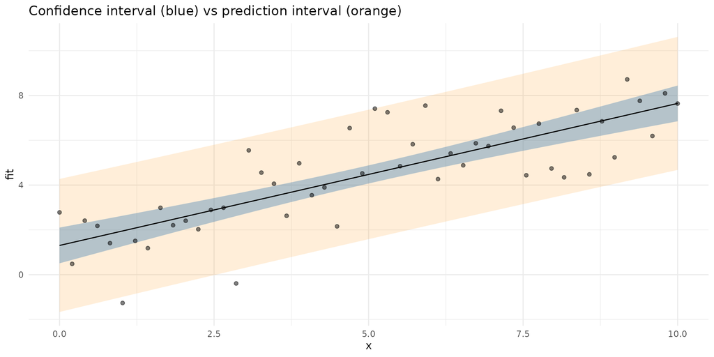

## Common visual encodings

| Encoding | Communicates | Caveats |
| --- | --- | --- |
| Error bars | A single interval at discrete points | Easy to over-interpret as “the” range |
| Ribbons/bands | Interval across a continuum | Implicit smoothing between points |
| Violin/density plots | Full shape of a distribution | Needs draws/samples, not just summary stats |
| Fan charts | Multiple nested intervals | Can be visually heavy |

## Error bars

- A mean (could be proportion) ± SD (obs)/SE(mean precision), a confidence/credible interval, fitted model-based adjusted effect
- For different groups
- Clear and simple
- Do not read the endpoints as hard boundaries.
- Says nothing about the shape of the underlying distribution

## Error bars

```r
library(ggplot2)
library(dplyr)

set.seed(2026)
groups_df <- data.frame(
  group = rep(c("A", "B", "C"), each = 30),
  value = c(rnorm(30, 5, 1), rnorm(30, 6, 1.5), rnorm(30, 5.5, 0.8))
)

summary_df <- groups_df |>
  group_by(group) |>
  summarise(mean = mean(value), se = sd(value) / sqrt(n()))

ggplot(summary_df, aes(group, mean)) +
  geom_point(size = 3, colour = "steelblue") +
  geom_errorbar(aes(ymin = mean - se, ymax = mean + se),
                width = 0.15, colour = "steelblue") +
  labs(title = "Group means with standard error bars",
       x = "Group", y = "Mean value") +
  theme_minimal()
```

## Error bars

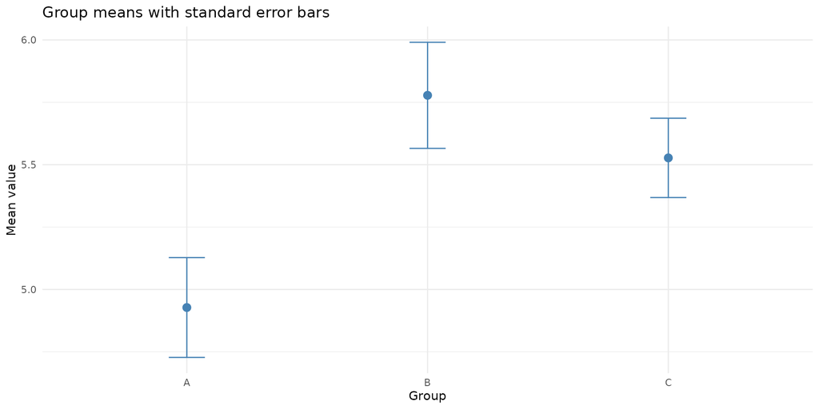

Not 100% clear, so need to read caption!

## Ribbon bands

- Same idea as error bars, but stretched across a continuum (e.g. time)
- Smooth interpolation between the computed points
- Caveat: smoothness could be artefact, not a model-based individual uncertainty feature

## Ribbon bands

```r
set.seed(2026)
n_steps <- 100
n_sims  <- 500

sims <- lapply(1:n_sims, function(i) {
  data.frame(sim = i, time = 1:n_steps, position = cumsum(rnorm(n_steps)))
}) |> bind_rows()

summary_df <- sims |>
  group_by(time) |>
  summarise(median = median(position),
            lower = quantile(position, 0.05),
            upper = quantile(position, 0.95))

ggplot(summary_df, aes(time)) +
  geom_ribbon(aes(ymin = lower, ymax = upper), alpha = 0.25, fill = "steelblue") +
  geom_line(aes(y = median), colour = "steelblue", linewidth = 1) +
  labs(title = "90% interval as a continuous ribbon",
       x = "Time", y = "Position") +
  theme_minimal()
```

## Ribbon bands

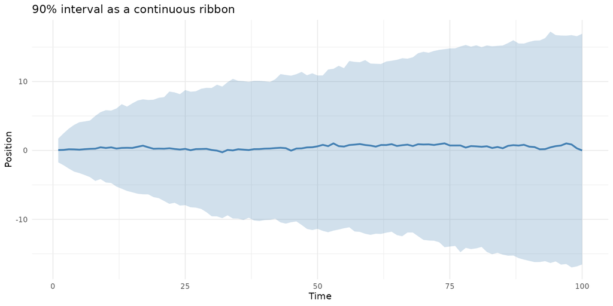

We have seen them last week (simulation ribbons). Do we see individual trajectories? Only “average” model-based uncertainty.

## Violin/density plots

- No collapsing to an interval
- Shows the entire shape of the distribution (bi-modality, skew, etc.)
- Trade-off: draws or samples needed to build it
  - Summary statistics not there

## Violin/density plots

```r
set.seed(2026)
groups_df <- data.frame(
  group = rep(c("A", "B"), each = 200),
  value = c(rnorm(200, 5, 1), c(rnorm(100, 4, 0.5), rnorm(100, 7, 0.5)))
)

ggplot(groups_df, aes(group, value)) +
  geom_violin(fill = "steelblue", alpha = 0.4) +
  geom_jitter(width = 0.05, alpha = 0.4, size = 0.8) +
  labs(title = "Violin plot: full distribution shape (note group B is bimodal)",
       x = "Group", y = "Value") +
  theme_minimal()
```

## Violin/density plots

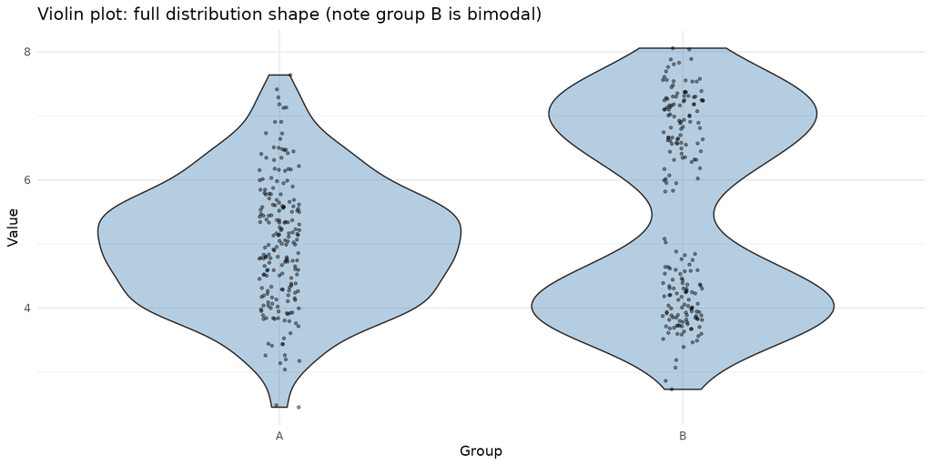

Require readers to think

## Fan charts

- Basically a ribbon with more layers
  - Several nested intervals (e.g. 50%/80%/95%) radiating from a common origin - - Typically for a forecast
- Packs more information than 1 band, but
  - Cost of visual weight

## Fan charts

```r
set.seed(2026)
summary_df <- sims |>
  group_by(time) |>
  summarise(
    median  = median(position),
    lower50 = quantile(position, 0.25), upper50 = quantile(position, 0.75),
    lower80 = quantile(position, 0.10), upper80 = quantile(position, 0.90),
    lower95 = quantile(position, 0.025), upper95 = quantile(position, 0.975)
  )

ggplot(summary_df, aes(time)) +
  geom_ribbon(aes(ymin = lower95, ymax = upper95), alpha = 0.15, fill = "steelblue") +
  geom_ribbon(aes(ymin = lower80, ymax = upper80), alpha = 0.25, fill = "steelblue") +
  geom_ribbon(aes(ymin = lower50, ymax = upper50), alpha = 0.4,  fill = "steelblue") +
  geom_line(aes(y = median), colour = "steelblue", linewidth = 1) +
  labs(title = "Fan chart: nested 50%/80%/95% intervals",
       x = "Time", y = "Position") +
  theme_minimal()
```

## Fan charts

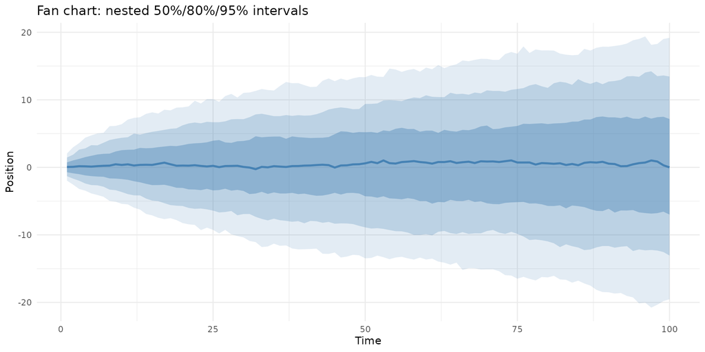

Good if you care about how uncertainty scale across levels

## Conclusion: sources and types of uncertainty

- Not all uncertainty is the same: sampling , model (even model form?), prediction
- A confidence interval and a prediction interval can produce visually identical ribbons, yet very different meanings
  - Plot alone won’t tell which you are looking at
- The four visual encodings (error bars, ribbons, violins, fan charts) are just containers: each can hold different uncertainty sources
  - Choosing the wrong pairing (or failing labels) $\to$ misleading
- Next question: good vs bad execution

# Lecture 2: Good and bad practice

## Recap: Lecture 1 - sources and types of uncertainty

- Three kinds of uncertainty: **sampling** (would my estimate change on repeat?), **model** (is the model form right?), **prediction** (where would a *new* observation land?)
- A mean interval and a prediction interval can produce an **identical-looking ribbon**
  - Same encoding, different meaning
- “Common visual encodings” table: error bars, ribbons, violins, fan charts: each a *container* that can hold different kinds of uncertainty

## Lecture 2: Good and bad practice

- “Dynamite plot” problem: why bar + error bar is the canonical example of an encoding that hides more than it reveals
- Showing distributions instead of summaries: when a violin/density beats a mean ± interval
- Discrete vs continuous: matching the encoding to the audience
- Worked good/bad examples of each encoding from this week’s readings

## Error bars: five ways to show the “same” uncertainty

Following Wilke (2019), Fig. 16.5 - the *same* sample, five different error bars

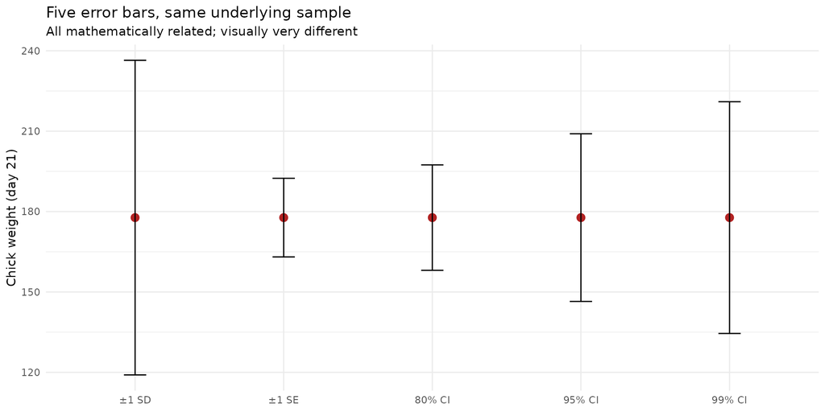

## Error bars: five ways to show the “same” uncertainty

- **Bad practice**: showing *one* of these with no label — the reader guesses whether it’s SD, SE, or a CI
- **Good practice**: pick one, state it explicitly in the axis/caption (“mean ± SE, n = 20”)

## Ribbons: linear fit vs non-linear spline

Following Wilke §16.3 - a straight-line confidence band is “well behaved”; a spline’s band hides increased *wiggliness*, not just vertical shift

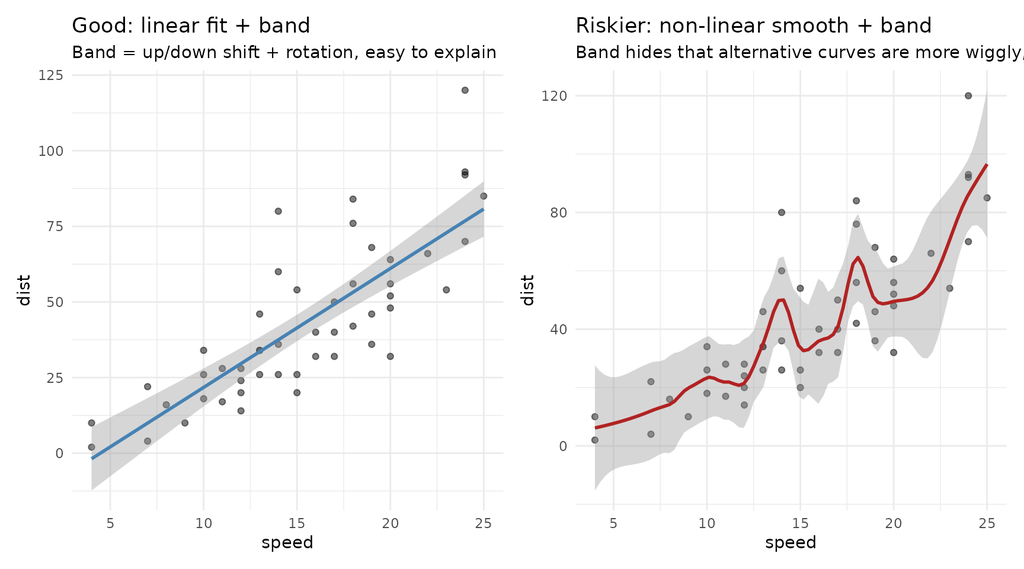

## Violin/density: dynamite plot vs distribution shown

Following Wilke 2019’s Fig. 9.1 “Visualizing many distributions at once” critique

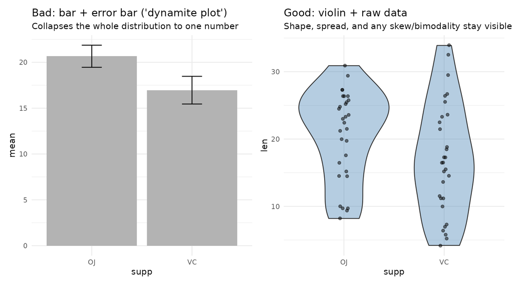

## The “dynamite plot” problem. And the fix

- The bar+error-bar plot hides that group VC has much more variance than and a different shape to OJ. Both groups look “similar” with a small SE
- The violin/jitter version shows the actual distributions

## Why bars are especially misleading here

- Bars imply a baseline of zero and a “filled” quantity.
  - Appropriate for counts/amounts, not means
- The error bar is often ±1 SE, ±1 SD, or a 95% CI. Again, *the plot doesn’t say which*, and the visual difference between these can be 4x
- Always label what an interval represents

## Fan charts: graded band vs confidence strip

Following Wilke (2019), Fig. 16.9: grading intervals helps up to a point; past that, strips/overlapping shading become hard to decode

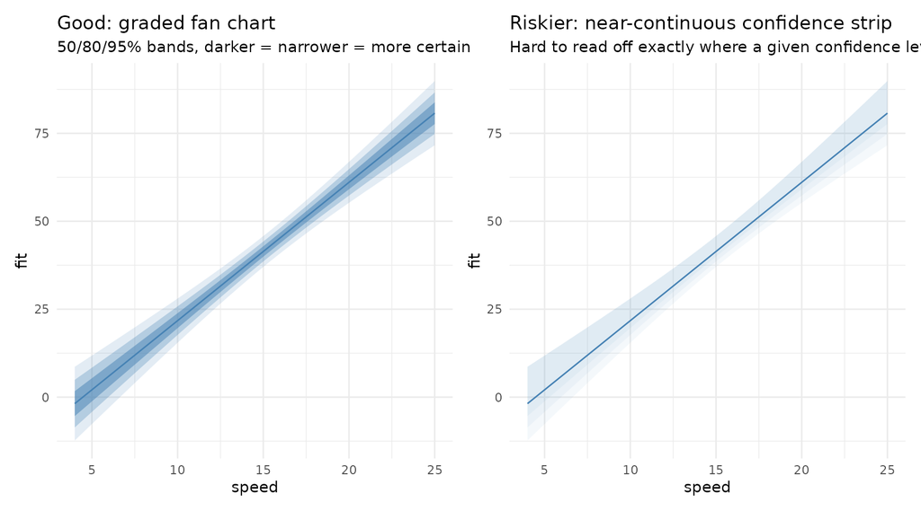

## Take-away for the discussion

- Every “bad” example above isn’t wrong data
  - **same numbers**, encoded in a way that either hides shape or hides which quantity is being shown
- The fix is rarely a totally different chart type: it’s usually *showing more of the distribution* (violin, graded bands, draws) or *labelling precisely* what the interval means

## Showing distributions instead of summaries

- **Density/violin plots**: full shape, but can be hard to read exact values
- **Quantile dotplots**: discretise a distribution into $n$ dots, each representing an equally-likely outcome.
  - Easier for many audiences to read as “frequency” rather than abstract density
- **Hypothetical outcome plots (HOPs)**: show one plausible draw at a time, in sequence. They are conceptually powerful, but not static-figure friendly

## Quantile dotplot: a worked example

Discretise a distribution into $n$ equally-likely dots, following Wilke §16.1 (Fig. 16.3)

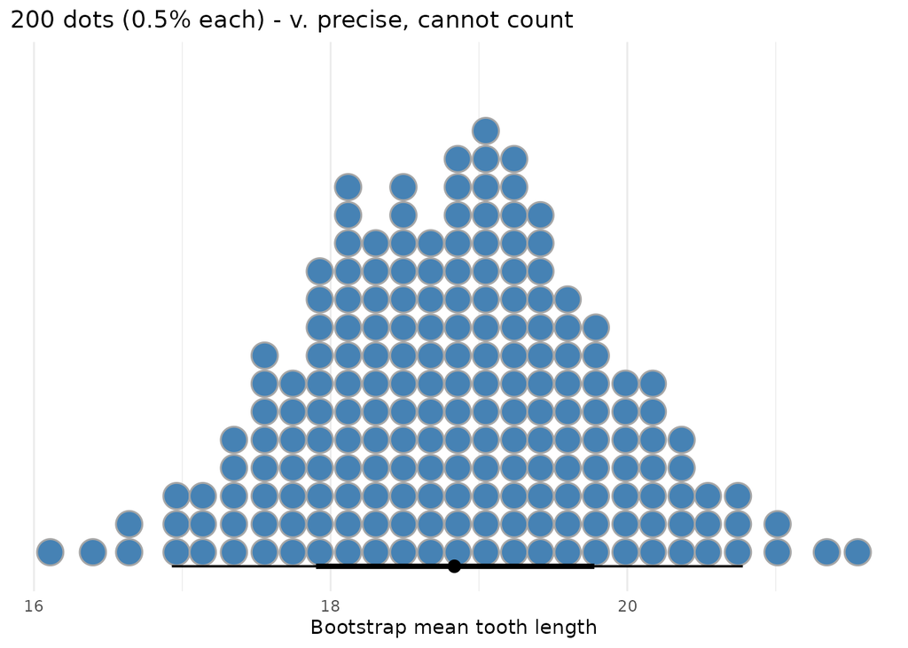

## Quantile dotplot: 50 dots vs 10 dots

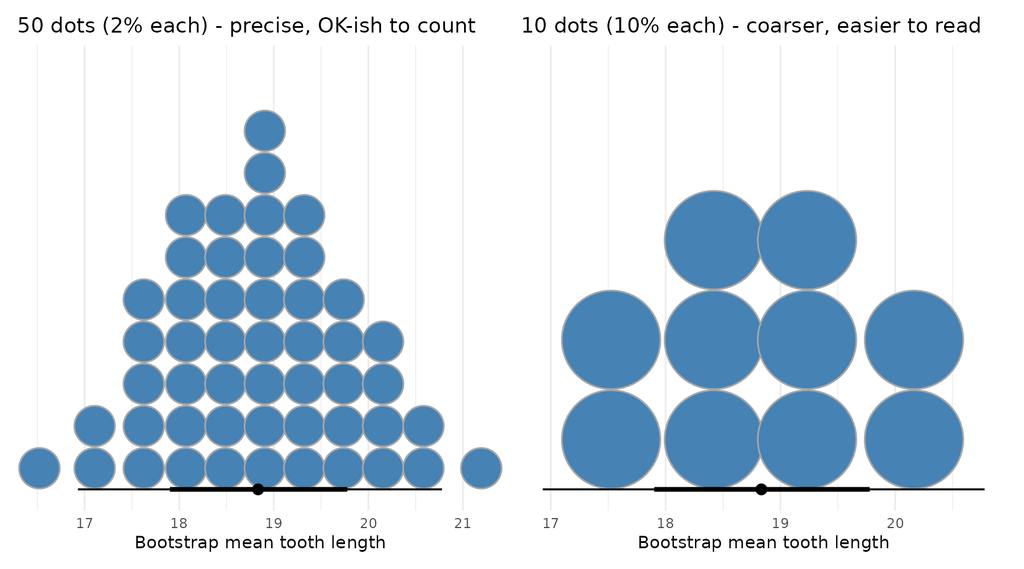

## Quantile dotplot: 50 dots vs 10 dots

- Each dot represents an equally-likely chunk of the bootstrap distribution of the mean, not a raw observation
- More dots $\to$ closer to the “true” shape but harder to perceive as discrete individual units
- Fewer dots $\to$ easier to read as a frequency statement (“about 1 in 10 estimates fall in this bin”), at some cost of precision — the same precision/readability trade-off Wilke makes with his election-outcome example

## Hypothetical outcome plots: cycling through plausible fits

Instead of one static band, show individual plausible outcomes *in sequence* (see Wilke §16.4)

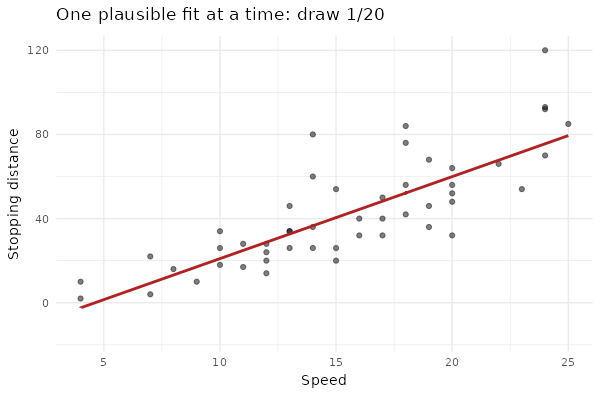

## HOP: static “print” fallback

For handouts or non-animated contexts, show a small sample of draws side by side instead

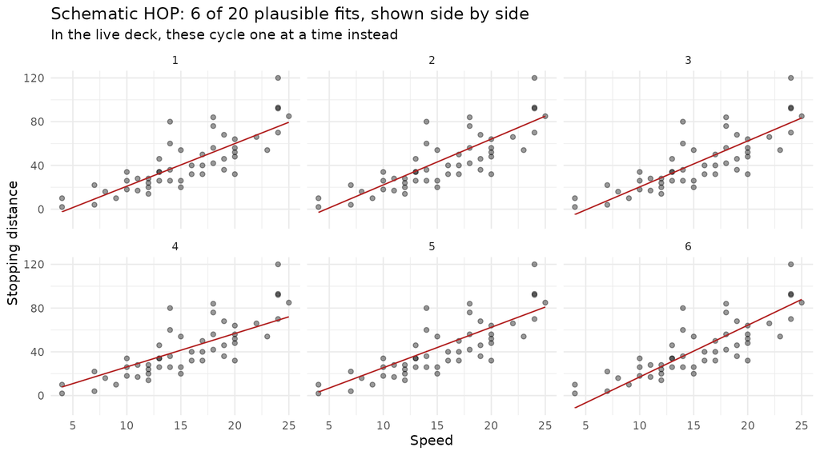

```r
subset_draws <- subset(draws, draw <= 6)

ggplot() +
  geom_point(data = cars, aes(speed, dist), alpha = 0.4) +
  geom_line(data = subset_draws, aes(speed, fit), colour = "firebrick") +
  facet_wrap(~ draw, nrow = 2) +
  labs(title = "Schematic HOP: 6 of 20 plausible fits, shown side by side",
       subtitle = "In the live deck, these cycle one at a time instead",
       x = "Speed", y = "Stopping distance") +
  theme_minimal()
```

## Why all of this matters (link back to Lecture 1’s ribbon)

- The confidence band from Lecture 1 is the same underlying uncertainty
  - the HOP just shows it as a *sequence of single draws* instead of an aggregated shape
- Static bands risk **deterministic construal**: viewers can start reading the band edge as a hard boundary
  - Watching individual lines appear and disappear works against that
- Trade-off: HOPs need an animated or interactive medium; static print/PDF export not directly possible $\to$ talk/slide-deck tool, not a report figure

## Discrete vs continuous: audience matters

- A clinician may find “60 out of 100 similar patients would have an outcome in this range” (quantile dotplot / icon array logic) more intuitive than a density curve
- A statistician may prefer the density curve for its precision
- There is no single “correct” encoding
  - Right choice depends on **who is reading the plot** and **what decision it supports**

## Reading for this week

- Wilke (2019): Visualizing many distributions at once (Chap. 9) and Visualizing uncertainty (Chap. 16) (and Chapter 25 if you feel strong)
- Handbook of Data Visualization: chapters touching on graphical perception and statistical graphics for inference, in particular Part III.9, “Smoothing Techniques for Visualisation”

## Looking ahead

- Tutorials: point estimates $\to$ CI ribbons $\to$ PI ribbons $\to$ bootstrap distributions shown as densities/violins/quantile dotplots
- Weeks 7-8: the same distributional thinking applies to network summary statistics (e.g. “what’s the distribution of this node’s centrality under re-sampling/bootstrapping the network?”)

161.307 - Reproducible Visualisation for Statistics